# 机器学习与因果推断 - 第六讲：面板数据与双重差分法

- 显示所有代码
- 隐藏所有代码
- 查看源代码

利用时间维度识别因果效应：完整讲义

作者

单位

陈志远

中国人民大学商学院

发布于

2026年4月14日

# 1 引言

本讲介绍三种利用**时间维度**识别因果效应的方法：面板数据分析（Panel Data）、双重差分法（Difference-in-Differences, DiD）以及合成控制法（Synthetic Control Method）。这些方法在经济学、公共政策评估和社会科学研究中有着广泛的应用，也是当前实证研究中最常用的因果识别策略之一。

本讲对应教材 Mixtape Ch. 8-10 的内容。

## 1.1 上节课回顾

在上一讲中，我们学习了**工具变量法**（Instrumental Variables, IV）来处理不可观测的混淆变量问题。工具变量法的核心在于找到一个满足两个条件的变量：

1. **相关性条件**：工具变量 $Z$ 与处理变量 $D$ 相关，$Cov(Z, D) \neq 0$
2. **排他性约束**：工具变量 $Z$ 只通过处理变量 $D$ 影响结果 $Y$

然而，工具变量法的一个重要局限是，好的工具变量往往很难找到。当我们无法找到合适的工具变量时，**面板数据方法**提供了一个替代方案——通过利用数据的时间维度，控制那些不随时间变化的混淆变量。

# 2 第一部分：面板数据与固定效应

## 2.1 什么是面板数据？

**面板数据**（Panel Data），也称为纵向数据（Longitudinal Data），是指对相同个体（个人、企业、地区、国家等）在多个时间点上进行重复观测的数据。面板数据的一般形式为：

$$Y_{it}, \quad i = 1, \ldots, N, \quad t = 1, \ldots, T$$

其中，$i$ 表示个体（cross-sectional unit），$t$ 表示时间（time period）。

与面板数据相对的两种基本数据类型是：

| 数据类型 | 观测方式 | 典型例子 |
| --- | --- | --- |
| 截面数据（Cross-sectional） | 不同个体在同一时间点 | 2020 年全国人口普查 |
| 时间序列（Time Series） | 同一对象在多个时间点 | 中国 GDP 年度数据 |
| **面板数据**（Panel Data） | **相同个体在多个时间点** | **各省份 2000–2020 年 GDP** |

面板数据同时兼具截面数据和时间序列数据的特征，这使其在因果推断中具有独特的优势。

## 2.2 面板数据的优势

面板数据的核心优势在于它允许我们控制**不随时间变化的个体特征**（time-invariant unobserved heterogeneity），从而解决遗漏变量偏误问题。

### 2.2.1 传统截面回归的问题

考虑一个简单的截面回归：

$$Y_i = \alpha + \beta D_i + \varepsilon_i$$

如果存在未观测的混淆变量 $U_i$ 同时影响 $D_i$ 和 $Y_i$，则 $U_i$ 被吸收进误差项 $\varepsilon_i$，导致 $Cov(D_i, \varepsilon_i) \neq 0$，OLS 估计有偏。

### 2.2.2 面板数据的解决方案

面板数据模型将误差项分解为两个部分：

$$Y_{it} = \delta D_{it} + u_i + \varepsilon_{it}$$

其中：

- $Y_{it}$：个体 $i$ 在时间 $t$ 的结果变量
- $D_{it}$：处理变量（可能随时间和个体变化）
- $u_i$：**个体固定效应**（individual fixed effect）——不随时间变化的个体特征，如能力、偏好、地理位置等
- $\varepsilon_{it}$：时变误差项（idiosyncratic error）

关键洞察：即使 $u_i$ 与 $D_{it}$ 相关（这正是传统截面回归有偏的原因），面板数据方法也可以通过**去均值化**消除 $u_i$ 的影响。

## 2.3 固定效应（Within）估计量

### 2.3.1 去均值化的完整推导

固定效应估计量的核心思想是对原始模型进行**去均值化**（demeaning），也称为组内变换（within transformation）。

**第一步**：对原始模型

$$Y_{it} = \delta D_{it} + u_i + \varepsilon_{it}$$

**第二步**：对每个个体 $i$，计算所有时间的平均值

$$\bar{Y}_i = \frac{1}{T}\sum_{t=1}^{T} Y_{it} = \delta \bar{D}_i + u_i + \bar{\varepsilon}_i$$

注意 $u_i$ 的均值仍然是 $u_i$（因为它不随时间变化）。

**第三步**：用 (1) 减去 (2)

$$Y_{it} - \bar{Y}_i = \delta(D_{it} - \bar{D}_i) + (u_i - u_i) + (\varepsilon_{it} - \bar{\varepsilon}_i)$$

$$\tilde{Y}_{it} = \delta \tilde{D}_{it} + \tilde{\varepsilon}_{it}$$

其中，波浪号 $\tilde{\cdot}$ 表示去均值后的变量。关键之处在于：

$$u_i - u_i = 0$$

个体固定效应被**完全消除**！对变换后的模型 (3) 进行 OLS 回归，即可得到 $\delta$ 的一致估计量——这就是**组内估计量**（within estimator）。

### 2.3.2 直观理解

固定效应模型的核心思想是”**自己跟自己比**”。例如，在研究教育对收入的影响时：

- 截面回归比较的是：张三（高学历）vs 李四（低学历）的收入差异——但张三和李四可能先天能力不同
- 固定效应比较的是：张三获得额外教育**前后**的收入变化——自动控制了张三的先天能力

这种方法自动控制了所有不随时间变化的个体差异（先天能力、家庭背景、地理位置等），无论这些差异是否可观测。

## 2.4 固定效应的关键假设与局限

### 2.4.1 严格外生性假设

固定效应模型的核心假设是**严格外生性**（Strict Exogeneity）：

$$E[\varepsilon_{it} \mid D_{i1}, D_{i2}, \ldots, D_{iT}, u_i] = 0$$

这意味着时变误差项 $\varepsilon_{it}$ 与**所有时期**的处理变量都不相关。这是一个相当强的假设，它排除了以下情况：

- **反馈效应**：过去的结果 $Y_{it-1}$ 影响当前的处理 $D_{it}$（动态面板）
- **预期效应**：未来的处理 $D_{it+1}$ 影响当前的结果 $Y_{it}$

**警告严格外生性 vs 同期外生性**

严格外生性要求误差项与**所有时期**的处理变量无关，而同期外生性（contemporaneous exogeneity）只要求 $E[\varepsilon_{it} \mid D_{it}, u_i] = 0$——即误差项与**同期**处理变量无关。固定效应估计量的一致性需要严格外生性（在 $T$ 固定的情况下）。

### 2.4.2 三大局限

1. **无法解决反向因果**：如果 $Y_{it}$ 同时影响 $D_{it}$（同时性），固定效应无法解决。例如，犯罪率高的城市会部署更多警察——固定效应无法消除这种反向因果。
2. **无法处理时变混淆变量**：固定效应只能消除不随时间变化的混淆变量。如果存在时变混淆变量 $X_{it}$ 同时影响 $D_{it}$ 和 $Y_{it}$，估计仍然有偏。
3. **无法估计时不变变量的效应**：如性别、种族等在固定效应模型中被消除，其效应无法估计。

### 2.4.3 何时使用固定效应

**提示适用场景**

- 存在不随时间变化的个体特征（能力、偏好、地理位置）
- 这些特征与处理变量相关（即存在 $Cov(u_i, D_{it}) \neq 0$）
- 处理变量在个体内有变异（有人从 0 变 1，或从 1 变 0）
- 严格外生性假设合理（无反馈效应）

# 3 第二部分：双重差分法

## 3.1 核心思想

**双重差分法**（Difference-in-Differences, DiD）是一种利用**自然实验**或**准实验**来估计因果效应的方法。它的基本思想是：比较处理组和对照组在处理前后的**变化差异**。

$$\hat{\delta}_{DiD} = \underbrace{(\bar{Y}_{T,post} - \bar{Y}_{T,pre})}_{\text{处理组的变化}} - \underbrace{(\bar{Y}_{C,post} - \bar{Y}_{C,pre})}_{\text{对照组的变化}}$$

直观地说：

- 第一层差分消除了组间的**固定差异**（组间异质性）
- 第二层差分消除了**共同时间趋势**
- 剩下的就是处理效应

## 3.2 历史溯源：John Snow 与霍乱

DiD 的思想可以追溯到 1854 年伦敦霍乱爆发期间 John Snow 的研究。当时主流观点认为霍乱通过”瘴气”（miasma）传播，而 Snow 假设霍乱通过受污染的水传播。

Snow 利用了一个**自然实验**：伦敦有两家自来水公司——Lambeth 公司和 Southwark & Vauxhall 公司。两家公司的供水区域在地理上高度重叠，但取水位置不同：

- **Lambeth 公司**：在 1852 年将取水口搬到了泰晤士河上游（远离污水排放口）
- **Southwark & Vauxhall 公司**：仍在下游取水（靠近污水排放口）

## 3.3 2×2 DiD 设计

标准的 DiD 设计涉及**四组**比较：

|  | 处理前（Pre） | 处理后（Post） | 变化 |
| --- | --- | --- | --- |
| 处理组（Treatment） | $\bar{Y}_{T,pre}$ | $\bar{Y}_{T,post}$ | $\Delta_T = \bar{Y}_{T,post} - \bar{Y}_{T,pre}$ |
| 对照组（Control） | $\bar{Y}_{C,pre}$ | $\bar{Y}_{C,post}$ | $\Delta_C = \bar{Y}_{C,post} - \bar{Y}_{C,pre}$ |
| **DiD** |  |  | $\hat{\delta} = \Delta_T - \Delta_C$ |

DiD 估计量也可以等价地表示为：

$$\hat{\delta}_{DiD} = (\bar{Y}_{T,post} - \bar{Y}_{C,post}) - (\bar{Y}_{T,pre} - \bar{Y}_{C,pre})$$

即”处理后组间差异”减去”处理前组间差异”。

## 3.4 平行趋势假设

DiD 识别的关键假设是**平行趋势假设**（Parallel Trends Assumption）：

> 如果没有处理，处理组和对照组的结果变量会遵循**相同的时间趋势**。

形式上：

$$E[Y(0)_{T,post} - Y(0)_{T,pre}] = E[Y(0)_{C,post} - Y(0)_{C,pre}]$$

其中 $Y(0)$ 表示没有处理时的潜在结果。

### 3.4.1 为什么平行趋势如此重要？

平行趋势假设的本质是：对照组的变化提供了处理组在**没有处理时本来会经历的变化**（反事实）。如果这个假设不成立——比如处理组本身就有更快的增长趋势——那么 DiD 会将这部分趋势差异错误地归因于处理效应。

### 3.4.2 不可检验性

**警告平行趋势假设无法直接检验**

我们只能观察处理前的趋势是否平行（这是必要条件），但这并不能保证处理后趋势也平行。处理前平行只是支持该假设的**间接证据**，而非充分条件。

实践中的应对方案包括：

1. 绘制**事件研究图**，检验处理前系数是否接近零
2. **安慰剂检验**：假设处理发生在更早时期
3. 使用不同的对照组进行**稳健性检验**

## 3.5 双向固定效应（TWFE）模型

DiD 可以通过以下**双向固定效应**（Two-Way Fixed Effects, TWFE）模型来估计：

$$Y_{it} = \alpha + \delta D_{it} + \gamma_i + \lambda_t + \varepsilon_{it}$$

其中：

- $\gamma_i$：**个体固定效应**——控制不随时间变化的个体特征
- $\lambda_t$：**时间固定效应**——控制所有个体共同面对的时间冲击（如宏观经济波动）
- $D_{it}$：处理变量（处理组且处理后 $= 1$，否则 $= 0$）
- $\delta$：处理效应（DiD 估计量）

### 3.5.1 DiD 与 TWFE 的等价性

对于标准的 2×2 DiD（两组、两期），TWFE 回归系数 $\hat{\delta}$ 恰好等于”差分之差”。简要证明如下：

在 TWFE 中，$\gamma_i$ 吸收了组间的固定差异，$\lambda_t$ 吸收了共同的时间趋势。去掉这两层固定效应后，$D_{it}$ 的系数捕捉的就是：处理组相对于对照组、在处理后相对于处理前的”额外”变化——这正是 DiD 估计量。

## 3.6 经典案例：Card & Krueger (1994)

### 3.6.1 研究背景

这篇论文是劳动经济学中最具影响力的实证研究之一。研究问题是：**最低工资提高会导致失业增加吗？**

传统经济学理论（竞争性劳动力市场模型）预测：最低工资提高 → 劳动力成本上升 → 企业裁员 → 就业下降。

### 3.6.2 研究设计

Card & Krueger 利用了一个经典的自然实验：

- **处理组**：新泽西州（NJ）快餐店——1992 年 4 月，新泽西州将最低工资从 $4.25 提高到 $5.05
- **对照组**：宾夕法尼亚州（PA）东部快餐店——最低工资保持不变（$4.25）
- **数据**：在最低工资提高前（1992 年 2 月）和提高后（1992 年 11 月）分别调查两州 410 家快餐店（Burger King、KFC、Wendy’s、Roy Rogers）的全职当量员工数（Full-Time Equivalent, FTE）

### 3.6.3 研究结果

|  | 新泽西州（NJ） | 宾夕法尼亚州（PA） | 差异 |
| --- | --- | --- | --- |
| 处理前（2 月） | 20.44 FTE | 23.33 FTE | -2.89 |
| 处理后（11 月） | 21.03 FTE | 21.17 FTE | -0.14 |
| **变化** | **+0.59** | **-2.16** | **+2.75** |

**DiD 估计**：$\hat{\delta} = (+0.59) - (-2.16) = +2.75$ FTE

**注记惊人发现**

新泽西州就业**增加**了 0.59 FTE，而宾夕法尼亚州就业**减少**了 2.16 FTE。DiD 估计为 +2.75 FTE（统计不显著），表明没有证据支持最低工资提高减少就业的传统观点。这一发现挑战了竞争性劳动力市场模型，推动了买方垄断（monopsony）模型等替代理论的发展。

### 3.6.4 争议与后续

这篇论文引发了巨大争议。Neumark & Wascher (2000) 使用薪资数据（而非电话调查数据）重新分析，得出了相反的结论。但后续大量研究（包括使用 administrative data 的分析）总体上支持了 Card & Krueger 的发现：适度的最低工资提高对就业的负面影响很小甚至不存在。

## 3.7 推断挑战：聚类标准误

面板数据中，同一个体的观测值往往存在**序列相关**（serial correlation）：

$$Cov(\varepsilon_{it}, \varepsilon_{is}) \neq 0 \quad \text{当 } t \neq s$$

这意味着传统的 OLS 标准误会**严重低估**真实的标准误，导致过多的假阳性（Bertrand, Duflo & Mullainathan, 2004）。

### 3.7.1 解决方案：聚类标准误

在个体层面进行**聚类**（clustered standard errors）：

- 允许同一个体内的误差项任意相关
- 提供更保守（更大）的标准误
- 在 DiD 中几乎是**必须的**

**警告聚类层级的选择**

聚类应在处理发生的层级进行。例如，若政策在「州」层面实施，则应在州层面聚类，而非在个体层面。聚类数量过少（< 50）时，可考虑使用野生自举法（wild bootstrap）。

## 3.8 事件研究设计

### 3.8.1 动态处理效应

处理效应可能随时间变化：

- **立即效应**：处理后立即出现
- **滞后效应**：处理一段时间后才出现
- **预期效应**：处理前就有反应（anticipation）

事件研究设计（Event Study Design）正是用来刻画这种**动态处理效应**的。

### 3.8.2 事件研究模型

$$Y_{it} = \alpha + \sum_{k=-m}^{-2} \beta_k D_{it}^k + \sum_{k=0}^{n} \beta_k D_{it}^k + \gamma_i + \lambda_t + \varepsilon_{it}$$

其中：

- $D_{it}^k$：指示变量，表示个体 $i$ 在处理后 $k$ 期（$k \geq 0$）或处理前 $|k|$ 期（$k < 0$）
- 通常省略 $k = -1$（处理前一期）作为参照基准（base period）
- 处理前系数 $\beta_k$（$k < 0$）用于**检验平行趋势**
- 处理后系数 $\beta_k$（$k \geq 0$）揭示**动态处理效应**

### 3.8.3 如何解读事件研究图

事件研究图的横轴是相对于处理的时间（事件时间），纵轴是处理效应大小。理想中：

- 处理前系数应**统计不显著**、接近零 → 支持平行趋势
- 处理后系数揭示效应出现的时间和持续性

如果预处理系数显著不为零或呈明显趋势，说明平行趋势假设可能不成立，DiD 估计可能有偏。

## 3.9 案例：ACA 医疗补助扩展

### 3.9.1 研究设计

- **处理组**：2014 年采纳 ACA 医疗补助扩展的州
- **对照组**：未采纳扩展的州
- **方法**：事件研究 + DiD

### 3.9.2 主要发现

1. **保险覆盖率**：扩展州的 Medicaid 覆盖率在扩展后显著提高，处理前系数接近零（支持平行趋势）
2. **死亡率**：扩展州的死亡率在扩展后下降约 0.13 百分点，尤其是与医疗可及性相关的死因（如心血管疾病、糖尿病）

这一研究有力地说明了医疗保险覆盖扩展对健康结局的正面影响。

## 3.10 安慰剂检验

安慰剂检验是一种强有力的**稳健性检验**方法。

### 3.10.1 实施步骤

1. 随机选择”假处理组”（保持处理组大小不变）
2. 估计 DiD
3. 重复多次（如 1,000 次）
4. 构建**安慰剂分布**（placebo distribution）
5. 比较真实估计与安慰剂分布

### 3.10.2 解释

如果真实估计落在安慰剂分布的**尾部**（如 5% 以外），说明在随机分配处理的情况下，不太可能得到如此极端的估计值，从而间接支持了真实效应的存在。这种推断逻辑类似于 Fisher 的精确检验（randomization inference）。

## 3.11 三重差分（DDD）

### 3.11.1 何时使用

当平行趋势假设在简单的 DiD 中不成立时，可以添加**第三个维度**进行比较。三重差分利用了一个不受政策影响的子群体作为额外对照。

### 3.11.2 模型设定

$$Y_{it} = \alpha + \beta_1 Treat_i + \beta_2 Post_t + \beta_3 Group_i + \delta(Treat_i \times Post_t \times Group_i) + \text{controls} + \varepsilon_{it}$$

### 3.11.3 Gruber (1994) 案例

这是最经典的 DDD 应用之一。

**研究问题**：强制产假福利（mandated maternity benefits）对工资和就业的影响。

**研究设计**：

- **第一重差分**：通过产假法的州 vs 未通过的州（处理 vs 对照）
- **第二重差分**：法律通过前 vs 通过后（前 vs 后）
- **第三重差分**：已婚育龄女性（直接受益群体）vs 其他群体（不受影响的群体）

**发现**：强制产假福利导致已婚育龄女性的工资下降约 5%，说明福利成本被**转嫁**给了目标群体的员工（而非由雇主承担）。这一结论证实了税收归宿理论的预测。

## 3.12 现代 DiD：交错处理的问题

### 3.12.1 现实复杂性

现实中，大多数政策并非在所有地区同时实施，而是”**交错**”（staggered）的——不同州或不同企业在不同时间采纳政策。

### 3.12.2 传统 TWFE 的问题

Goodman-Bacon (2021) 的开创性工作揭示了传统 TWFE 在交错处理下的严重问题：

传统 TWFE 估计量实际上是多个 2×2 DiD 的**加权平均**，但权重可能不合理——特别是，**已经接受处理的单位会被隐含地用作后来处理单位的”对照组”**。如果处理效应随时间变化（例如，效应逐渐增强或减弱），这会导致估计偏误，甚至可能产生**负权重**，使得估计的符号与真实效应相反。

### 3.12.3 现代 DiD 方法

针对交错处理，近年来发展了一系列新方法：

| 方法 | 核心思想 |
| --- | --- |
| Callaway & Sant’Anna (2021) | 以”组-时间”为单位估计 ATT，使用从未处理或尚未处理的单位作为对照 |
| Sun & Abraham (2021) | 交互加权（IW）估计量，避免”已处理对照”问题 |
| Gardner (2021) | 两步法：先估计固定效应，再估计处理后效应 |
| Borusyak, Jaravel & Spiess (2024) | 插补法（imputation），构建反事实后直接比较 |

**提示实践建议**

如果你的研究涉及交错处理时间，强烈建议: (1) 先报告传统 TWFE 结果；(2) 使用至少一种现代 DiD 方法进行稳健性检验；(3) 报告 Goodman-Bacon 分解以展示 TWFE 权重结构。

## 3.13 Python 实现：DiD 模拟

### 3.13.1 数据生成与 TWFE 估计

**点击查看完整代码：DiD 模拟与 TWFE 估计**

```
=======================================================
TWFE 估计结果
=======================================================
  真实处理效应:   2.000
  估计处理效应:   1.978
  聚类标准误:     0.050
  t 统计量:       39.470
  p 值:           0.000000
=======================================================
```

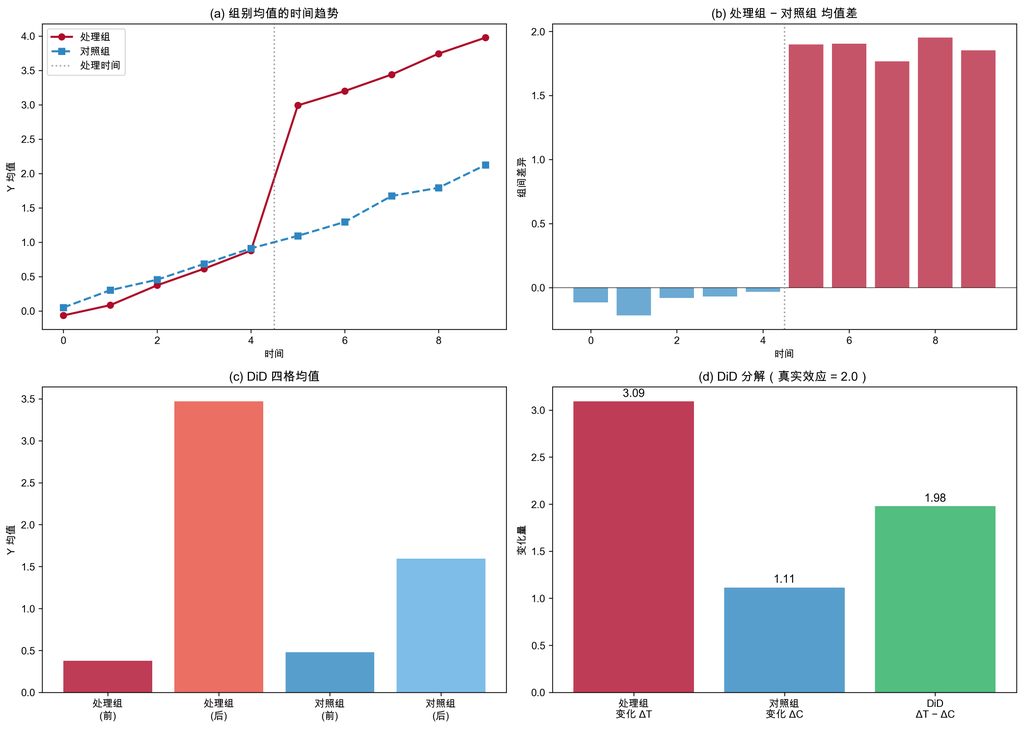

双重差分可视化：处理组与对照组在处理前后的变化

```python
import statsmodels.api as sm

# ── 数据生成 ──
np.random.seed(42)
n_units = 200
n_periods = 10

units = np.repeat(np.arange(n_units), n_periods)
periods = np.tile(np.arange(n_periods), n_units)
treatment = (units < n_units // 2).astype(int)
post = (periods >= 5).astype(int)
D = treatment * post

unit_fe = np.repeat(np.random.normal(0, 1, n_units), n_periods)
time_fe = np.tile(np.linspace(0, 2, n_periods), n_units)
true_effect = 2.0

Y = unit_fe + time_fe + true_effect * D + np.random.normal(0, 0.5, len(units))

data = pd.DataFrame({
    'unit': units, 'period': periods, 'Y': Y,
    'D': D, 'treatment': treatment, 'post': post
})

# ── TWFE 估计 ──
from linearmodels.panel import PanelOLS

panel = data.set_index(['unit', 'period'])
model = PanelOLS(
    dependent=panel['Y'],
    exog=sm.add_constant(panel['D']),
    entity_effects=True,
    time_effects=True
)
result = model.fit(cov_type='clustered', cluster_entity=True)

print("=" * 55)
print("TWFE 估计结果")
print("=" * 55)
print(f"  真实处理效应:   {true_effect:.3f}")
print(f"  估计处理效应:   {result.params['D']:.3f}")
print(f"  聚类标准误:     {result.std_errors['D']:.3f}")
print(f"  t 统计量:       {result.tstats['D']:.3f}")
print(f"  p 值:           {result.pvalues['D']:.6f}")
print("=" * 55)

# ── 可视化：四面板图 ──
fig, axes = plt.subplots(2, 2, figsize=(14, 10))

# 面板 1：组别均值的时间趋势
means = data.groupby(['period', 'treatment'])['Y'].mean().unstack()
axes[0, 0].plot(means.index, means[1], 'o-', color='#AE0B2A', label='处理组', linewidth=2)
axes[0, 0].plot(means.index, means[0], 's--', color='#2E86C1', label='对照组', linewidth=2)
axes[0, 0].axvline(x=4.5, color='gray', linestyle=':', alpha=0.7, label='处理时间')
axes[0, 0].set_xlabel('时间')
axes[0, 0].set_ylabel('Y 均值')
axes[0, 0].set_title('(a) 组别均值的时间趋势')
axes[0, 0].legend()

# 面板 2：组间差异的时间变化
diff = means[1] - means[0]
axes[0, 1].bar(diff.index, diff, color=['#2E86C1']*5 + ['#AE0B2A']*5, alpha=0.7)
axes[0, 1].axhline(y=0, color='black', linewidth=0.5)
axes[0, 1].axvline(x=4.5, color='gray', linestyle=':', alpha=0.7)
axes[0, 1].set_xlabel('时间')
axes[0, 1].set_ylabel('组间差异')
axes[0, 1].set_title('(b) 处理组 − 对照组 均值差')

# 面板 3：DiD 示意图
pre_treat = means[1].iloc[:5].mean()
post_treat = means[1].iloc[5:].mean()
pre_ctrl = means[0].iloc[:5].mean()
post_ctrl = means[0].iloc[5:].mean()

axes[1, 0].bar(['处理组\n(前)', '处理组\n(后)', '对照组\n(前)', '对照组\n(后)'],
               [pre_treat, post_treat, pre_ctrl, post_ctrl],
               color=['#AE0B2A', '#E74C3C', '#2E86C1', '#5DADE2'], alpha=0.8)
axes[1, 0].set_ylabel('Y 均值')
axes[1, 0].set_title(f'(c) DiD 四格均值')

# 面板 4：DiD 分解
delta_t = post_treat - pre_treat
delta_c = post_ctrl - pre_ctrl
did_est = delta_t - delta_c

bars = axes[1, 1].bar(['处理组\n变化 ΔT', '对照组\n变化 ΔC', 'DiD\nΔT − ΔC'],
                       [delta_t, delta_c, did_est],
                       color=['#AE0B2A', '#2E86C1', '#27AE60'], alpha=0.8)
axes[1, 1].axhline(y=0, color='black', linewidth=0.5)
axes[1, 1].set_ylabel('变化量')
axes[1, 1].set_title(f'(d) DiD 分解（真实效应 = {true_effect}）')
for bar, val in zip(bars, [delta_t, delta_c, did_est]):
    axes[1, 1].text(bar.get_x() + bar.get_width()/2, bar.get_height() + 0.05,
                    f'{val:.2f}', ha='center', fontsize=11, fontweight='bold')

plt.tight_layout()
plt.show()
```

### 3.13.2 事件研究图

**点击查看完整代码：事件研究图绘制**

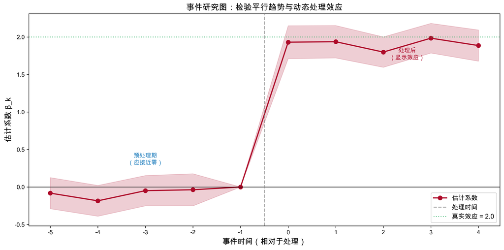

事件研究图：处理效应的动态变化，预处理系数应接近零

```python
# ── 构建事件研究数据 ──
data_es = data.copy()
data_es['treat_period'] = 5  # 所有处理组在第5期受到处理

# 事件时间
data_es['event_time'] = data_es['period'] - data_es['treat_period']

# 只对处理组构建事件时间哑变量
event_dummies = pd.get_dummies(data_es['event_time'], prefix='k').astype(int)
# 与 treatment 交互
for col in event_dummies.columns:
    event_dummies[col] = event_dummies[col] * data_es['treatment']

# 去掉 k=-1 作为基准期
event_dummies = event_dummies.drop('k_-1', axis=1)
data_es = pd.concat([data_es.reset_index(drop=True), event_dummies], axis=1)

# 加入个体和时间哑变量
unit_dummies = pd.get_dummies(data_es['unit'], prefix='unit', drop_first=True)
time_dummies = pd.get_dummies(data_es['period'], prefix='time', drop_first=True)

k_cols = [c for c in event_dummies.columns]
X = pd.concat([data_es[k_cols], unit_dummies, time_dummies], axis=1).astype(float)
X = sm.add_constant(X)

model_es = sm.OLS(data_es['Y'], X).fit(
    cov_type='cluster', cov_kwds={'groups': data_es['unit']}
)

# 提取事件时间系数
event_times = sorted([int(c.split('_')[1]) for c in k_cols])
coefs = [model_es.params[f'k_{k}'] for k in event_times]
ci_low = [model_es.conf_int().loc[f'k_{k}', 0] for k in event_times]
ci_high = [model_es.conf_int().loc[f'k_{k}', 1] for k in event_times]

# 加入基准期（k=-1，系数=0）
event_times_full = sorted(event_times + [-1])
idx_base = event_times_full.index(-1)
coefs.insert(idx_base, 0)
ci_low.insert(idx_base, 0)
ci_high.insert(idx_base, 0)

# ── 绘图 ──
fig, ax = plt.subplots(figsize=(12, 6))

ax.fill_between(event_times_full, ci_low, ci_high, alpha=0.2, color='#AE0B2A')
ax.plot(event_times_full, coefs, 'o-', color='#AE0B2A', linewidth=2, markersize=7, label='估计系数')
ax.axhline(y=0, color='black', linewidth=0.8)
ax.axvline(x=-0.5, color='gray', linestyle='--', alpha=0.7, label='处理时间')
ax.axhline(y=true_effect, color='#27AE60', linestyle=':', alpha=0.7, label=f'真实效应 = {true_effect}')

ax.set_xlabel('事件时间（相对于处理）', fontsize=13)
ax.set_ylabel('估计系数 β_k', fontsize=13)
ax.set_title('事件研究图：检验平行趋势与动态处理效应', fontsize=14)
ax.legend(fontsize=11)
ax.set_xticks(event_times_full)

# 标注区域
ax.annotate('预处理期\n（应接近零）', xy=(-3, 0.3), fontsize=10, color='#2E86C1',
            ha='center', fontweight='bold')
ax.annotate('处理后\n（显示效应）', xy=(2.5, true_effect - 0.3), fontsize=10, color='#AE0B2A',
            ha='center', fontweight='bold')

plt.tight_layout()
plt.show()
```

### 3.13.3 安慰剂检验分布

**点击查看完整代码：安慰剂检验**

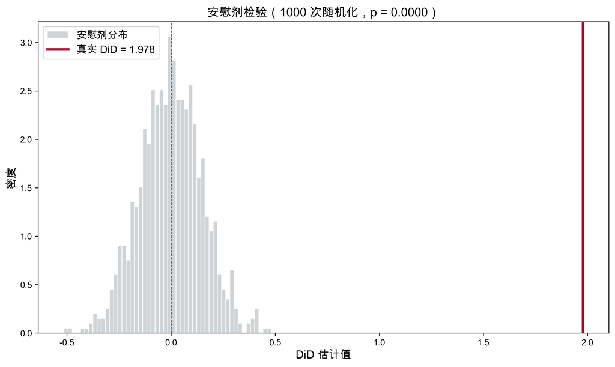

安慰剂检验：随机分配处理后的 DiD 分布，红线为真实估计值

```
真实 DiD 估计: 1.9780
安慰剂 p 值:   0.0000
安慰剂均值:    -0.0008
安慰剂标准差:  0.1486
```

```python
# ── 安慰剂检验 ──
n_placebo = 1000
placebo_estimates = []

for _ in range(n_placebo):
    # 随机分配处理组
    fake_treatment = np.zeros(n_units, dtype=int)
    fake_treatment[np.random.choice(n_units, n_units // 2, replace=False)] = 1
    fake_treatment_full = np.repeat(fake_treatment, n_periods)
    fake_D = fake_treatment_full * post

    # 简单 DiD 计算
    fake_data = pd.DataFrame({
        'Y': Y, 'D': fake_D,
        'treatment': fake_treatment_full, 'post': np.tile(post[:n_periods], n_units)
    })
    means_t = fake_data[fake_data['treatment'] == 1].groupby('post')['Y'].mean()
    means_c = fake_data[fake_data['treatment'] == 0].groupby('post')['Y'].mean()

    if len(means_t) == 2 and len(means_c) == 2:
        did_p = (means_t.iloc[1] - means_t.iloc[0]) - (means_c.iloc[1] - means_c.iloc[0])
        placebo_estimates.append(did_p)

placebo_estimates = np.array(placebo_estimates)

# 真实 DiD 估计
real_means_t = data[data['treatment'] == 1].groupby('post')['Y'].mean()
real_means_c = data[data['treatment'] == 0].groupby('post')['Y'].mean()
real_did = (real_means_t.iloc[1] - real_means_t.iloc[0]) - (real_means_c.iloc[1] - real_means_c.iloc[0])

# p值
p_value = np.mean(np.abs(placebo_estimates) >= np.abs(real_did))

fig, ax = plt.subplots(figsize=(10, 6))
ax.hist(placebo_estimates, bins=50, density=True, alpha=0.7, color='#BDC3C7', edgecolor='white',
        label='安慰剂分布')
ax.axvline(x=real_did, color='#AE0B2A', linewidth=3, label=f'真实 DiD = {real_did:.3f}')
ax.axvline(x=0, color='black', linewidth=0.8, linestyle='--')

ax.set_xlabel('DiD 估计值', fontsize=13)
ax.set_ylabel('密度', fontsize=13)
ax.set_title(f'安慰剂检验（{n_placebo} 次随机化，p = {p_value:.4f}）', fontsize=14)
ax.legend(fontsize=12)

plt.tight_layout()
plt.show()

print(f"真实 DiD 估计: {real_did:.4f}")
print(f"安慰剂 p 值:   {p_value:.4f}")
print(f"安慰剂均值:    {placebo_estimates.mean():.4f}")
print(f"安慰剂标准差:  {placebo_estimates.std():.4f}")
```

## 3.14 R 语言对照

以下是使用 R 实现相同分析的代码，供熟悉 R 的读者参考。

### 3.14.1 使用 fixest 包进行 TWFE 估计

```r
# 安装（如果需要）
# install.packages("fixest")

library(fixest)

# TWFE 估计
did_model <- feols(Y ~ D | unit + period, data = panel_data,
                   cluster = ~unit)
summary(did_model)

# 事件研究
es_model <- feols(Y ~ i(event_time, treatment, ref = -1) | unit + period,
                  data = panel_data, cluster = ~unit)
iplot(es_model, main = "事件研究图")
```

### 3.14.2 使用 did 包进行 Callaway & Sant’Anna 估计

```r
# install.packages("did")
library(did)

# Callaway & Sant'Anna (2021)
cs_result <- att_gt(
  yname = "Y",
  tname = "period",
  idname = "unit",
  gname = "first_treat",  # 首次处理时间
  data = panel_data,
  control_group = "notyettreated"  # 使用"尚未处理"组作对照
)
summary(cs_result)

# 汇总为总体 ATT
agg_cs <- aggte(cs_result, type = "simple")
summary(agg_cs)

# 动态效应
agg_dynamic <- aggte(cs_result, type = "dynamic")
ggdid(agg_dynamic)
```

# 4 第三部分：合成控制法

## 4.1 从 DiD 到合成控制

DiD 方法在多数情况下表现良好，但当**只有一个（或极少数）处理单位**时面临挑战：

- 一个省份实施了独特的政策
- 一家公司被收购
- 一个国家经历了制度变迁

此时，对照组的选择具有很大的**主观性**——选择不同的对照组可能得到截然不同的结果。

## 4.2 合成控制法的核心思想

**合成控制法**（Synthetic Control Method, SCM）由 Abadie & Gardeazabal (2003) 和 Abadie, Diamond & Hainmueller (2010) 提出，其核心思想是：

> 不要选择单一的对照组，而是用多个对照单位的**加权组合**来**构建**一个”合成”的对照——使其在处理前的特征和趋势上尽可能接近处理单位。

### 4.2.1 优势

- **数据驱动**的权重选择，避免了研究者的主观选择
- 合成单位与处理单位在处理前的**预测变量**上相似
- **透明**：可以清楚地看到哪些单位贡献了多少权重

## 4.3 经典案例：California Proposition 99

### 4.3.1 研究背景

Abadie, Diamond & Hainmueller (2010) 研究了 1988 年加州通过 Proposition 99 对香烟消费的影响。Proposition 99 大幅提高了加州的香烟税（每包增加 25 美分），使加州成为当时控烟力度最大的州之一。

**挑战**：加州是**唯一**的处理单位，无法直接使用传统 DiD。

### 4.3.2 合成控制的构建

使用 38 个没有在同期大幅提高香烟税的州作为”**捐赠池**”（donor pool），寻找最优权重组合来合成一个”假加州”——即加州如果没有通过 Proposition 99 时的反事实。

### 4.3.3 主要发现

- 合成加州与真实加州在 1988 年前的香烟消费趋势**高度吻合**
- 1988 年后，真实加州的香烟消费开始显著低于合成加州
- 估计效应：Proposition 99 使加州的人均香烟消费**减少约 20–30 包/人/年**
- 主要贡献权重的州包括犹他州、内华达州、蒙大拿州和科罗拉多州

## 4.4 形式化框架

### 4.4.1 优化问题

给定 $J$ 个对照单位（捐赠池），寻找权重向量 $\mathbf{W} = (w_2, \ldots, w_{J+1})'$ 最小化处理单位与合成单位在处理前预测变量上的差距：

$$\min_{\mathbf{W}} \|\mathbf{X}_1 - \mathbf{X}_0 \mathbf{W}\|_V = \sqrt{(\mathbf{X}_1 - \mathbf{X}_0 \mathbf{W})' \mathbf{V} (\mathbf{X}_1 - \mathbf{X}_0 \mathbf{W})}$$

**约束条件**：

$$w_j \geq 0 \quad \text{（非负权重）}, \qquad \sum_{j=2}^{J+1} w_j = 1 \quad \text{（权重之和为 1）}$$

其中：

- $\mathbf{X}_1$：处理单位的预测变量向量（维度 $K \times 1$）
- $\mathbf{X}_0$：对照单位的预测变量矩阵（维度 $K \times J$）
- $\mathbf{V}$：预测变量重要性的对角矩阵（通常通过交叉验证选择）

### 4.4.2 处理效应估计

处理后 $t$ 期的处理效应为：

$$\hat{\tau}_t = Y_{1t} - \sum_{j=2}^{J+1} w_j^* Y_{jt} = Y_{1t} - Y_{1t}^{synth}$$

即处理单位的实际结果减去合成对照的预测结果。

## 4.5 安慰剂推断（Placebo Inference）

由于只有一个处理单位，无法使用传统的统计推断（大样本理论不适用）。合成控制法使用**空间安慰剂检验**：

1. 依次将捐赠池中的**每个单位**视为”假处理单位”
2. 为每个”假处理单位”构建合成控制
3. 估计”假处理效应”
4. 比较**真实效应与安慰剂分布**

如果真实效应远大于大部分安慰剂效应，则说明效应是”异常的”——不太可能仅由噪声产生。

更正式地，可以构建以下检验统计量：

$$\text{RMSPE ratio} = \frac{RMSPE_{post}}{RMSPE_{pre}}$$

其中 $RMSPE$ 是均方根预测误差（Root Mean Squared Prediction Error）。预处理拟合好（$RMSPE_{pre}$ 小）但处理后偏差大（$RMSPE_{post}$ 大）的单位，其比值会很大。

## 4.6 Python 实现：合成控制模拟

**点击查看完整代码：合成控制法模拟**

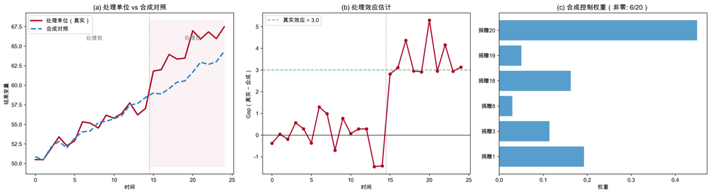

合成控制法模拟：真实处理单位 vs 合成对照

```
处理后平均 gap: 3.463（真实效应: 3.0）
处理前 RMSPE:   0.762
处理后 RMSPE:   3.554
```

```python
from scipy.optimize import minimize

np.random.seed(42)

# ── 参数设置 ──
n_donors = 20       # 捐赠池大小
n_pre = 15           # 处理前期数
n_post = 10          # 处理后期数
T = n_pre + n_post
treatment_effect = 3.0  # 真实处理效应

# ── 生成数据 ──
# 处理单位的潜在结果 (无处理)
trend = np.linspace(50, 65, T)
treated_y0 = trend + np.random.normal(0, 1, T)
# 处理后加入效应
treated_y = treated_y0.copy()
treated_y[n_pre:] += treatment_effect

# 捐赠池（每个单位有自己的截距和微弱趋势差异）
donor_y = np.zeros((n_donors, T))
for j in range(n_donors):
    intercept = np.random.normal(0, 5)
    slope_diff = np.random.normal(0, 0.1)
    donor_y[j] = trend + intercept + slope_diff * np.arange(T) + np.random.normal(0, 1, T)

# ── 求解合成控制权重 ──
X1_pre = treated_y[:n_pre]
X0_pre = donor_y[:, :n_pre]

def objective(w):
    synth = X0_pre.T @ w
    return np.sum((X1_pre - synth) ** 2)

constraints = {'type': 'eq', 'fun': lambda w: np.sum(w) - 1}
bounds = [(0, 1)] * n_donors
w0 = np.ones(n_donors) / n_donors

result_opt = minimize(objective, w0, method='SLSQP', bounds=bounds, constraints=constraints)
w_star = result_opt.x

# 合成对照的完整时间序列
synth_y = donor_y.T @ w_star

# ── 可视化 ──
fig, axes = plt.subplots(1, 3, figsize=(18, 5))

# 面板 1：真实 vs 合成
time = np.arange(T)
axes[0].plot(time, treated_y, '-', color='#AE0B2A', linewidth=2.5, label='处理单位（真实）')
axes[0].plot(time, synth_y, '--', color='#2E86C1', linewidth=2.5, label='合成对照')
axes[0].axvline(x=n_pre - 0.5, color='gray', linestyle=':', alpha=0.7)
axes[0].fill_between([n_pre - 0.5, T - 1], axes[0].get_ylim()[0], axes[0].get_ylim()[1],
                     alpha=0.05, color='#AE0B2A')
axes[0].set_xlabel('时间')
axes[0].set_ylabel('结果变量')
axes[0].set_title('(a) 处理单位 vs 合成对照')
axes[0].legend()
axes[0].text(n_pre / 2, axes[0].get_ylim()[1] * 0.95, '处理前', ha='center', fontsize=10, color='gray')
axes[0].text(n_pre + n_post / 2, axes[0].get_ylim()[1] * 0.95, '处理后', ha='center', fontsize=10, color='gray')

# 面板 2：处理效应（Gap）
gap = treated_y - synth_y
axes[1].plot(time, gap, 'o-', color='#AE0B2A', linewidth=2, markersize=5)
axes[1].axhline(y=0, color='black', linewidth=0.8)
axes[1].axvline(x=n_pre - 0.5, color='gray', linestyle=':', alpha=0.7)
axes[1].axhline(y=treatment_effect, color='#27AE60', linestyle='--', alpha=0.7,
                label=f'真实效应 = {treatment_effect}')
axes[1].set_xlabel('时间')
axes[1].set_ylabel('Gap（真实 − 合成）')
axes[1].set_title('(b) 处理效应估计')
axes[1].legend()

# 面板 3：权重分布
nonzero_mask = w_star > 0.01
labels = [f'捐赠{i+1}' for i in range(n_donors)]
nonzero_weights = w_star[nonzero_mask]
nonzero_labels = [labels[i] for i in range(n_donors) if nonzero_mask[i]]

axes[2].barh(range(len(nonzero_weights)), nonzero_weights, color='#2E86C1', alpha=0.8)
axes[2].set_yticks(range(len(nonzero_weights)))
axes[2].set_yticklabels(nonzero_labels)
axes[2].set_xlabel('权重')
axes[2].set_title(f'(c) 合成控制权重（非零: {nonzero_mask.sum()}/{n_donors}）')

plt.tight_layout()
plt.show()

# 输出统计
print(f"\n处理后平均 gap: {gap[n_pre:].mean():.3f}（真实效应: {treatment_effect}）")
print(f"处理前 RMSPE:   {np.sqrt(np.mean(gap[:n_pre]**2)):.3f}")
print(f"处理后 RMSPE:   {np.sqrt(np.mean(gap[n_pre:]**2)):.3f}")
```

## 4.7 R 语言对照：合成控制

```r
# install.packages("Synth")
library(Synth)

# 准备数据（Synth 包格式）
dataprep_out <- dataprep(
  foo = panel_data,
  predictors = c("predictor1", "predictor2", "predictor3"),
  predictors.op = "mean",
  dependent = "outcome",
  unit.variable = "unit_id",
  time.variable = "year",
  treatment.identifier = 1,       # 处理单位 ID
  controls.identifier = 2:39,      # 捐赠池 ID
  time.predictors.prior = 1970:1987,
  time.optimize.ssr = 1970:1987,
  time.plot = 1970:2000
)

# 运行合成控制
synth_out <- synth(dataprep_out)

# 绘图
path.plot(synth_out, dataprep_out,
          Main = "处理单位 vs 合成对照")
gaps.plot(synth_out, dataprep_out,
          Main = "处理效应（Gap）")

# 查看权重
synth.tables(synth_out, dataprep_out)$tab.w
```

# 5 总结

## 5.1 三种方法比较

本讲介绍了三种利用时间维度识别因果效应的方法。它们各有特点和适用场景：

| 方法 | 核心假设 | 适用场景 | 主要优势 | 主要局限 |
| --- | --- | --- | --- | --- |
| **固定效应** | 严格外生性 | 面板数据，时变处理 | 控制时不变混淆 | 无法处理反向因果和时变混淆 |
| **DiD** | 平行趋势 | 政策评估，自然实验 | 直观，易于实施 | 依赖平行趋势（不可检验） |
| **合成控制** | 合成单位近似反事实 | 单一处理单位 | 数据驱动，透明 | 需要大捐赠池、长时间序列 |

## 5.2 方法选择指南

1. **多个处理单位 + 面板数据** → DiD（标准选择）
2. **单一处理单位 + 时间序列** → 合成控制法
3. **处理在单位内有变异** → 固定效应
4. **政策 staggered adoption** → 现代 DiD 方法（Callaway & Sant’Anna 等）

## 5.3 关键公式汇总

| 概念 | 公式 | 说明 |
| --- | --- | --- |
| 面板数据模型 | $Y_{it} = \delta D_{it} + u_i + \varepsilon_{it}$ | $u_i$ 为个体固定效应 |
| 去均值变换 | $\tilde{Y}_{it} = \delta \tilde{D}_{it} + \tilde{\varepsilon}_{it}$ | 消除 $u_i$ |
| DiD 估计量 | $\hat{\delta} = (\bar{Y}_{T,post} - \bar{Y}_{T,pre}) - (\bar{Y}_{C,post} - \bar{Y}_{C,pre})$ | 差分之差 |
| TWFE | $Y_{it} = \alpha + \delta D_{it} + \gamma_i + \lambda_t + \varepsilon_{it}$ | 双向固定效应 |
| 平行趋势 | $E[Y(0)_{T,post} - Y(0)_{T,pre}] = E[Y(0)_{C,post} - Y(0)_{C,pre}]$ | 核心识别假设 |
| 合成控制权重 | $\min_{\mathbf{W}} \\|\mathbf{X}_1 - \mathbf{X}_0 \mathbf{W}\\|$ s.t. $w_j \geq 0, \sum w_j = 1$ | 数据驱动构建反事实 |

## 5.4 关键检查清单

以下是使用本讲方法时应检查的核心事项：

**固定效应模型**：

- 严格外生性假设是否合理？
- 是否存在反向因果？
- 处理变量在个体内是否有足够变异？

**双重差分法**：

- 平行趋势假设是否合理？
- 是否绘制了事件研究图？
- 标准误是否在适当层级进行了聚类？
- 是否进行了安慰剂检验？
- 如涉及交错处理，是否使用了现代 DiD 方法？

**合成控制法**：

- 捐赠池是否足够大？
- 处理前拟合是否良好（$RMSPE_{pre}$ 小）？
- 是否进行了空间安慰剂检验？

## 5.5 下一讲预告

**第七讲：断点回归设计（Regression Discontinuity Design）**

当处理在某个**分数/阈值**处发生不连续变化时，我们可以利用断点附近个体的局部随机性来估计因果效应。下一讲将涵盖：

- 清晰断点（Sharp RD）vs 模糊断点（Fuzzy RD）
- 带宽选择与局部多项式回归
- 稳健性检验（McCrary 密度检验、敏感性分析）
- 经典应用案例

## 5.6 课后思考

1. **在你的研究领域**，能否找到一个适合用 DiD 方法分析的自然实验？处理组和对照组是什么？平行趋势假设是否合理？
2. **关于 TWFE 的局限**：假设你正在研究一项在不同省份、不同年份先后实施的环保政策对 GDP 的影响。为什么传统 TWFE 可能给出有偏的估计？你会使用哪种现代 DiD 方法来应对？
3. **关于合成控制的”不要外推”**：为什么合成控制法要求权重非负且和为 1？违反这些约束可能导致什么问题？在什么情况下，你可能会考虑放松这些约束？

# 6 参考文献

1. Abadie, A., Diamond, A., & Hainmueller, J. (2010). Synthetic Control Methods for Comparative Case Studies: Estimating the Effect of California’s Tobacco Control Program. *Journal of the American Statistical Association*, 105(490), 493-505.
2. Abadie, A., & Gardeazabal, J. (2003). The Economic Costs of Conflict: A Case Study of the Basque Country. *American Economic Review*, 93(1), 113-132.
3. Angrist, J. D., & Pischke, J. S. (2009). *Mostly Harmless Econometrics: An Empiricist’s Companion*. Princeton University Press.
4. Bertrand, M., Duflo, E., & Mullainathan, S. (2004). How Much Should We Trust Differences-in-Differences Estimates? *Quarterly Journal of Economics*, 119(1), 249-275.
5. Borusyak, K., Jaravel, X., & Spiess, J. (2024). Revisiting Event-Study Designs: Robust and Efficient Estimation. *Review of Economic Studies*, 91(6), 3253-3285.
6. Callaway, B., & Sant’Anna, P. H. (2021). Difference-in-Differences with Multiple Time Periods. *Journal of Econometrics*, 225(2), 200-230.
7. Card, D., & Krueger, A. B. (1994). Minimum Wages and Employment: A Case Study of the Fast-Food Industry in New Jersey and Pennsylvania. *American Economic Review*, 84(4), 772-793.
8. Goodman-Bacon, A. (2021). Difference-in-Differences with Variation in Treatment Timing. *Journal of Econometrics*, 225(2), 254-277.
9. Gruber, J. (1994). The Incidence of Mandated Maternity Benefits. *American Economic Review*, 84(3), 622-641.
10. Miller, S., Johnson, N., & Wherry, L. R. (2021). Medicaid and Mortality: New Evidence From Linked Survey and Administrative Data. *Quarterly Journal of Economics*, 136(3), 1783-1829.
11. Sun, L., & Abraham, S. (2021). Estimating Dynamic Treatment Effects in Event Studies with Heterogeneous Treatment Effects. *Journal of Econometrics*, 225(2), 175-199.

**联系方式**

- 邮箱：chenzhiyuan@rmbs.ruc.edu.cn
- 办公室：919
- Office Hours：邮件或微信预约

*本讲义基于 Angrist & Pischke (2009) “Mostly Harmless Econometrics” 和 Cunningham (2021) “Causal Inference: The Mixtape” Ch. 8-10 整理而成。*